# Airline Delay Prediction

2020-03-30

# 1 Introduction

Flight is number one choices of travelling transportation nowadays. It serves in comfort, speed, and long-distance trip. However, any positives usually followed by some disadvantages. Some cases in flights would hamper our journey, especially the most common one, **flight delay**. Here we will try to put up some machine learning in action, to predict whether the flight is more likely to be postponed or not.

## 1.1 Data Explanation

The dataset here contains all flights from Newark Liberty International Airport to Charlotte Douglas International Airport in 2013, including some variables like the scheduled time, departure delay, carrier, etc. Also another dataset of weather condition in 2013 recorded per hour, containing informations like wind speed, wind gust, humidity, etc.

## 1.2 Business Case

Customers prefer to choose flight with less delay, or if the delay is unavoidable, they were notified first. By making a machine learning model to predict whether a flight should be delayed or not, we can reduce the number of “sudden delay” and give more satisfaction to our customers, which would probably attract more customers to choose our airline.

## 1.3 Load Library and Data

Here I will use bunch of libraries, all including libraries for data wrangling and building machine learning model (also evaluation). The data I will use will be stored in two objects named `flight` for flight information and `weather` for weather information.

```r
library(dplyr) # Data wrangling
library(lubridate) # Dealing with datetime
library(ggplot2) # Visualization
library(caret) # Model pre-processing
library(keras) # Neural Network Model
library(randomForest) # Random Forest Model
library(MLmetrics) # Model Evaluation
library(lime) # Model interpretation
```

```r
flight <- read.csv("data-train-flight.csv")
weather <- read.csv("data-train-weather.csv")
```

# 2 Data Wrangling

## 2.1 `Flight` Table

**1. First we need to handle missing values**

```r
colSums(is.na(flight))
```

```
          year          month            day       dep_time sched_dep_time
             0              0              0            111              0
     dep_delay sched_arr_time      arr_delay        carrier         flight
           111              0            120              0              0
       tailnum         origin           dest       distance           hour
            48              0              0              0              0
        minute      time_hour
             0              0
```

```r
table(is.na(flight))
```

```
FALSE  TRUE
78048   390
```

```r
prop.table(table(is.na(flight)))*100
```

```
    FALSE      TRUE
99.502792  0.497208
```

In total, there are 390 missing values from 78438 observations, or just $\pm$ 0.5%. Technically, we can omit these rows.

```r
flight_set <- na.omit(flight)
```

Re-check it again

```r
colSums(is.na(flight_set))
```

```
          year          month            day       dep_time sched_dep_time
             0              0              0              0              0
     dep_delay sched_arr_time      arr_delay        carrier         flight
             0              0              0              0              0
       tailnum         origin           dest       distance           hour
             0              0              0              0              0
        minute      time_hour
             0              0
```

**2. Delete Non-Informative Variable**

Let’s take another glance on our flight dataset.

```r
head(flight_set)
```

```
  year month day dep_time sched_dep_time dep_delay sched_arr_time arr_delay
1 2013     1   1      629            630        -1            833 Not Delay
2 2013     1   1      643            645        -2            848 Not Delay
3 2013     1   1      811            815        -4           1016     Delay
4 2013     1   1     1010           1015        -5           1210 Not Delay
5 2013     1   1     1211           1215        -4           1413     Delay
6 2013     1   1     1314           1315        -1           1505 Not Delay
  carrier flight tailnum origin dest distance hour minute           time_hour
1      US   1019  N426US    EWR  CLT      529    6     30 2013-01-01 06:00:00
2      US    926  N178US    EWR  CLT      529    6     45 2013-01-01 06:00:00
3      US    675  N654AW    EWR  CLT      529    8     15 2013-01-01 08:00:00
4      US   1103  N162UW    EWR  CLT      529   10     15 2013-01-01 10:00:00
5      EV   4135  N21537    EWR  CLT      529   12     15 2013-01-01 12:00:00
6      US   1615  N177US    EWR  CLT      529   13     15 2013-01-01 13:00:00
```

Prior to make a machine learning model, there are several columns that is considered non-informative

- Columns that only has one level, such as `year` that only has *2013* as its observations. These columns would do nothing to our model. This is also the case for `origin`, `dest`, and `distance` variable, which only have *EWR*, *CLT*, and *529*, respectively.
- In contrast, is columns with too many levels, usually character-type. Unless we are doing visualization, or making an NLP model, these observations would less likely to be useful. In this table, those are variables like `tailnum` and `flight`.
- I find out that the `time_hour` variable has no information left in it since the day and month have already been extracted. We can delete this column as well.

```r
table(flight_set$carrier, flight_set$arr_delay)
```

```
     Delay Not Delay
  EV   754       828
  UA     1         1
  US   761      2149
```

- There are 3 different carriers, but *UA* has only two flights the last 11 months, so we can assume that this is a rare observations and wouldn’t do much to our model. Also the `delay` on the other two flights are near to equal, so it wouldn’t give much improvement to our model. This means, we can remove this column.

```r
flight_set %>% select(-year,-carrier,-flight, -tailnum, -origin, -dest, -distance, -time_hour)-> flight_fix
```

**3. Feature Extraction**

This functions will convert the integer time into a vector length 2 containing `hour` and `minute` in character format. For instance, if the **sched_arr_time** is `613`, this function will return it as `"6"` and `"13"`.

```r
apply_split <- function(data){

  time_split <- function(time){
    if (nchar(time)==3){
      hour_time <- substr(time,1,1)
      minute_time <- substr(time,2,3)
    } else {
      hour_time <- substr(time,1,2)
      minute_time <- substr(time,3,4)
    }
    return(c(hour_time,minute_time))
  }

  temp <- sapply(data, time_split)
  return(t(temp))
}
```

Main feature extraction for this case is, converting `sched_arr_time` variable, which is in integer type, into character, using function I provided above. Our expected final output is the scheduled duration of the flight, based on the scheduled arrived time substracted with scheduled departure. While the information we need from `dep_time` is just `dep_delay`, so we don’t need this column anymore. Also the hour and minute in this table, was extracted from `sched_dep_time` column.

```r
flight_fix %>%
  mutate(hour_sched_arr = apply_split(sched_arr_time)[,1]) %>%
  mutate(minute_sched_arr = apply_split(sched_arr_time)[,2]) %>%
  mutate(sched_dep = paste(hour,":",minute,sep = "")) %>%
  mutate(sched_arr = paste(hour_sched_arr,":",minute_sched_arr,sep = "")) %>%
  mutate(duration = hm(sched_arr)-hm(sched_dep)) %>%
  select(-dep_time, -sched_dep_time, -sched_arr_time,-hour_sched_arr, -minute_sched_arr, -sched_arr, -sched_dep, -minute) %>%
  mutate(duration = hour(duration)*60 + minute(duration)) %>%
  select(month,day,hour,dep_delay,duration, arr_delay)-> flight_final
```

```r
head(flight_final)
```

```
  month day hour dep_delay duration arr_delay
1     1   1    6        -1      123 Not Delay
2     1   1    6        -2      123 Not Delay
3     1   1    8        -4      121     Delay
4     1   1   10        -5      115 Not Delay
5     1   1   12        -4      118     Delay
6     1   1   13        -1      110 Not Delay
```

Now we have all variables we needed for building a machine learning model, here some explanations for table above :

- `month`, `day`, `hour` all will be used to join with `weather table`
- `dep_delay` and `duration` will be the predictors for machine learning model.
- `arr_delay` is our target variable

## 2.2 `Weather` Table

**1. First we need to handle missing values**

```r
colSums(is.na(weather))
```

```
      year      month        day       hour       temp       dewp      humid
         0          0          0          0          1          1          1
  wind_dir wind_speed  wind_gust     precip   pressure      visib  time_hour
       247          1       6270          0        827          0          0
```

```r
nrow(weather)
```

```
[1] 7989
```

`wind_gust` variable has an extreme **NA**. With 6270 missing values from only 7989 observations, or $\pm$ 78.5%. Variable `pressure` also has $\pm$ 10% of missing values. These two will do nothing to our model, so we can remove them.

```r
weather_set <- select(weather,-wind_gust, -pressure)
```

Re-check it again

```r
colSums(is.na(weather_set))
```

```
      year      month        day       hour       temp       dewp      humid
         0          0          0          0          1          1          1
  wind_dir wind_speed     precip      visib  time_hour
       247          1          0          0          0
```

```r
table(is.na(weather_set))
```

```
FALSE  TRUE
95617   251
```

```r
prop.table(table(is.na(weather_set)))*100
```

```
     FALSE       TRUE
99.7381817  0.2618183
```

With only 0.26% missing values, we can technically delete these observations. But, doing so would do more harm on our future analysis, since the data is time-series lookalike data (a data with regular time-setting), thus, an imputation is better for this one. Let’s look closely at the `wind_speed` variable

```r
summary(weather_set$wind_speed)
```

```
    Min.  1st Qu.   Median     Mean  3rd Qu.     Max.     NA's
   0.000    5.754    9.206    9.508   12.659 1048.361        1
```

The gap betwenn the 3rd quartile and the maximum value is very large. This shows that outlier exists in this variable and thus it’s better to use **median imputation**

```r
medImp <- preProcess(weather_set, "medianImpute")
weather_set <- predict(medImp, weather_set)
```

Re-check it again

```r
colSums(is.na(weather_set))
```

```
      year      month        day       hour       temp       dewp      humid
         0          0          0          0          0          0          0
  wind_dir wind_speed     precip      visib  time_hour
         0          0          0          0          0
```

**2. Delete Non-Informative Variable**

Since all of the variables are numeric, we can do feature selection by looking at the summary. Variables with either low range, low-level, or near zero variance can be omitted.

```r
summary(weather_set)
```

```
      year          month             day            hour
 Min.   :2013   Min.   : 1.000   Min.   : 1.0   Min.   : 0.00
 1st Qu.:2013   1st Qu.: 3.000   1st Qu.: 8.0   1st Qu.: 5.00
 Median :2013   Median : 6.000   Median :16.0   Median :11.00
 Mean   :2013   Mean   : 6.012   Mean   :15.7   Mean   :11.49
 3rd Qu.:2013   3rd Qu.: 9.000   3rd Qu.:23.0   3rd Qu.:17.00
 Max.   :2013   Max.   :11.000   Max.   :31.0   Max.   :23.00

      temp             dewp           humid           wind_dir
 Min.   : 10.94   Min.   :-9.04   Min.   : 13.95   Min.   :  0
 1st Qu.: 42.08   1st Qu.:28.04   1st Qu.: 46.67   1st Qu.:120
 Median : 57.92   Median :44.60   Median : 62.05   Median :220
 Mean   : 57.12   Mean   :43.07   Mean   : 62.47   Mean   :196
 3rd Qu.: 71.96   3rd Qu.:60.08   3rd Qu.: 78.65   3rd Qu.:280
 Max.   :100.04   Max.   :75.92   Max.   :100.00   Max.   :360

   wind_speed           precip             visib
 Min.   :   0.000   Min.   :0.000000   Min.   : 0.120
 1st Qu.:   5.754   1st Qu.:0.000000   1st Qu.:10.000
 Median :   9.206   Median :0.000000   Median :10.000
 Mean   :   9.508   Mean   :0.004923   Mean   : 9.352
 3rd Qu.:  12.659   3rd Qu.:0.000000   3rd Qu.:10.000
 Max.   :1048.361   Max.   :1.210000   Max.   :10.000

               time_hour
 2013-11-03 01:00:00:   2
 2013-01-01 01:00:00:   1
 2013-01-01 02:00:00:   1
 2013-01-01 03:00:00:   1
 2013-01-01 04:00:00:   1
 2013-01-01 05:00:00:   1
 (Other)            :7982
```

- `year` only has one level, we can delete it then.
- `time_hour` gives us no information since the day and month have already been extracted. We can remove this column as well.

```r
weather_set %>% select(-year,-time_hour) -> weather_fix
```

Now let’s see which variable has a variance relatively close to 0

```r
predVar <- vector()
for (i in 1:ncol(weather_fix)){
  predVar[i] <- round(var(weather_fix[,i]),4)
}
```

```r
data.frame(Variable = colnames(weather_fix), Variance = predVar)
```

```
     Variable   Variance
1       month     9.9383
2         day    77.0180
3        hour    47.8376
4        temp   325.6980
5        dewp   385.0169
6       humid   394.1751
7    wind_dir 11634.7174
8  wind_speed   163.8426
9      precip     0.0012
10      visib     3.6023
```

As we can see, `precip` variable has a variance near to zero, while `visib` is not near to zero, but compared to other variable, the variance is relatively low, and can be defined as **near-zero**, so we can remove these two variables.

```r
weather_final <- select(weather_fix, c(-precip,-visib))
```

Finally we have this table

```r
head(weather_final)
```

```
  month day hour  temp  dewp humid wind_dir wind_speed
1     1   1    1 39.02 26.06 59.37      270   10.35702
2     1   1    2 39.02 26.96 61.63      250    8.05546
3     1   1    3 39.02 28.04 64.43      240   11.50780
4     1   1    4 39.92 28.04 62.21      250   12.65858
5     1   1    5 39.02 28.04 64.43      260   12.65858
6     1   1    6 37.94 28.04 67.21      240   11.50780
```

## 2.3 Join Table

After tidying both tables, we can join them using the `left_join()` function from `dplyr`. Three columns that intersect both table are `month`, `day` and `hour`.

```r
flight_final %>%
  left_join(weather_final, by = c("month","day","hour")) -> airline
head(airline)
```

```
  month day hour dep_delay duration arr_delay  temp  dewp humid wind_dir
1     1   1    6        -1      123 Not Delay 37.94 28.04 67.21      240
2     1   1    6        -2      123 Not Delay 37.94 28.04 67.21      240
3     1   1    8        -4      121     Delay 39.92 28.04 62.21      250
4     1   1   10        -5      115 Not Delay 41.00 28.04 59.65      260
5     1   1   12        -4      118     Delay    NA    NA    NA       NA
6     1   1   13        -1      110 Not Delay 39.20 28.40 69.67      330
  wind_speed
1   11.50780
2   11.50780
3   10.35702
4   13.80936
5         NA
6   16.11092
```

It seems like we stumble with another missing values.

```r
colSums(is.na(airline))
```

```
     month        day       hour  dep_delay   duration  arr_delay       temp
         0          0          0          0          0          0         12
      dewp      humid   wind_dir wind_speed
        12         12         12         12
```

```r
table(is.na(airline))
```

```
FALSE  TRUE
49374    60
```

```r
prop.table(table(is.na(airline)))
```

```
     FALSE       TRUE
0.99878626 0.00121374
```

60 from total observations, or just about $\pm$ 0.12%, and all came from the same 12 flight observations. So I think it wouldn’t be a problem if we remove these rows.

```r
airline <- na.omit(airline)
```

As I recall, we only use `month`, `day`, and `hour` to cross/intersect our **flight** and **weather** table, while the information we needed from those three variables are all represented by the variables in **weather** table, so it is safe to remove these columns.

```r
airline %>% select(-month,-day,-hour) -> airline
```

I’ll also reorder the columns by shifting the target variable `arr_delay` to the right corner, just to tidy up a little bit.

```r
airline %>% select(1:2,4:8,arr_delay) -> airline
```

Now here is the table we’ll be working on to find the best machine learning model for prediction

```r
head(airline)
```

```
  dep_delay duration  temp  dewp humid wind_dir wind_speed arr_delay
1        -1      123 37.94 28.04 67.21      240   11.50780 Not Delay
2        -2      123 37.94 28.04 67.21      240   11.50780 Not Delay
3        -4      121 39.92 28.04 62.21      250   10.35702     Delay
4        -5      115 41.00 28.04 59.65      260   13.80936 Not Delay
6        -1      110 39.20 28.40 69.67      330   16.11092 Not Delay
7        -3      116 37.94 24.08 57.04      290    9.20624 Not Delay
```

# 3 Exploratory Data Analysis

Before we get into model fitting, let’s explore our data a little bit to see whether we need another pre-processing or not.

**1. Which carrier has the highest number of delay?**

```r
flight_set %>%
  group_by(carrier,arr_delay) %>%
  count() -> airViz1
airViz1
```

```
# A tibble: 6 x 3
# Groups:   carrier, arr_delay [6]
  carrier arr_delay     n
  <fct>   <fct>     <int>
1 EV      Delay       754
2 EV      Not Delay   828
3 UA      Delay         1
4 UA      Not Delay     1
5 US      Delay       761
6 US      Not Delay  2149
```

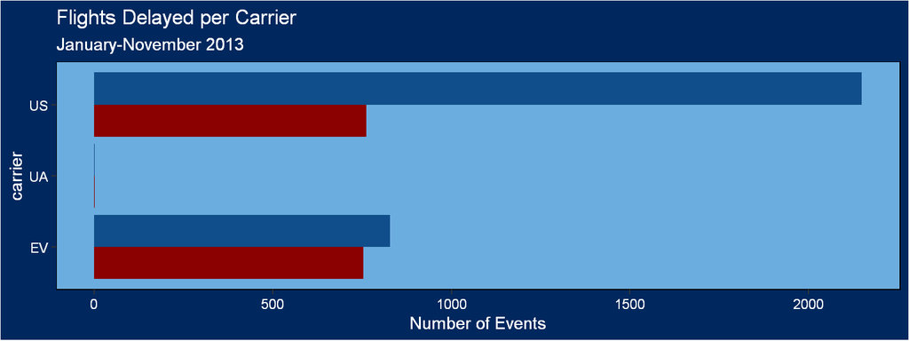

```r
ggplot(airViz1, aes(x = carrier, y = n)) + geom_col(aes(fill = arr_delay),position = "dodge") + coord_flip() +
  scale_fill_manual(values = c("darkred","dodgerblue4")) +
  labs(title = "Flights Delayed per Carrier", subtitle = "January-November 2013", y = "Number of Events", y = "Carrier") +
  theme_airline + theme(legend.position = "none")
```

**UA** airline rarely flight, so we can ignore this observations. While **US** and **EV** airlines have a very slight difference in numbers of delay, so I think none of the airlines need the model the most (all airlines need the model). Also none of the airline that has more delays than non-delays.

**2. Target Variable**

Our target variable is `arr_delay`, which tells us whether the flight should be (or should’ve been) delayed or not. It is important to check the proportion of target variable in all machine learning analysis to see whether we need to do upsampling/downsampling.

```r
table(airline$arr_delay)
```

```
    Delay Not Delay
     1510      2972
```

```r
prop.table(table(airline$arr_delay))
```

```
    Delay Not Delay
0.3369032 0.6630968
```

```r
table(airline$arr_delay)/nrow(filter(airline, arr_delay == "Delay"))
```

```
    Delay Not Delay
 1.000000  1.968212
```

The comparison is almost 2:1, which clearly indicates the imbalance of the target variable. Thus, an **upsampling/downsampling** is needed.

# 4 Model Pre-Processing

Prior to make a machine learning model, we have several pre-processings to do before fitting in to the function.

## 4.1 Sample Scaling

In machine learning, when the target variable is unbalance, it is necessary to scale the sample. The purpose is, to let our model learns the behaviour of both target variable the best way possible. If the class is unbalanced, let’s say `70-30` in percentage, the model will tend to learn the behaviour of the first class, thus resulting in high error in the second class. Now there are two methods of sample lifting, i.e **upsampling** (lifting with respect to the superior class), or **downsampling** (vice versa). Here’s the trade off of both method.

> Upsampling :
- More observations means the model learns better
- Repeating data might result in an overfitting, also our model is less reliable.
- Useful when dealing with small dataset.

> Downsampling :
- Without repetitive observations, our model is more reliable.
- Reducing observation would reduce the accuracy as the model has less data to learn to.
- Useful when dealing with big dataset.

In this case, with less than 5000 observations, which is considered small in terms of machine learning, we’ll use upsampling.

```r
airline <- upSample(airline[,-ncol(airline)], airline$arr_delay)
head(airline)
```

```
  dep_delay duration  temp  dewp humid wind_dir wind_speed Class
1        -4      121 39.92 28.04 62.21      250   10.35702 Delay
2         8      118 37.94 24.08 57.04      290    9.20624 Delay
3        -4      123 33.98 15.08 45.43      310   12.65858 Delay
4        19      127 33.08 12.92 42.84      320   10.35702 Delay
5        -2      110 24.08  8.96 51.93      330    6.90468 Delay
6        -4      123 24.08  8.96 51.93      310    3.45234 Delay
```

```r
nrow(airline)
```

```
[1] 5944
```

We now have almost 6000 observations thanks to the upsampling, here’s a little prove of how the class is balanced now

```r
table(airline$Class)
```

```
    Delay Not Delay
     2972      2972
```

```r
prop.table(table(airline$Class))
```

```
    Delay Not Delay
      0.5       0.5
```

## 4.2 Cross Validation

Is a usual method to split the observed data into two, i.e `train` and `validation`. The purpose is to avoid overfitting, by seeing how stable the performance of the model in the managed data, compared to the unseen data. If a model has high accuracy in train data and decreases dramatically in validation data, the model has high-variance and tend to overfit.

Generally, `70-30` to `90-10` splitting is acceptable, here I will split my data into `70-30` percentage, and by using `rsample` package we can use **stratified random sampling** method, which will divide sample by a certain strata, in this case, `Class` (our target variable). The purpose is to keep the class as balanced as the original data.

```r
set.seed(16)
library(rsample)
idx <- initial_split(airline,0.7,Class)
train_air <- training(idx)
val_air <- testing(idx)
```

## 4.3 X-Y Splitting

X-Y Splitting is a step to separate the predictors and label into two different objects. While it is not necessary, it’s a better practice to do so.

```r
# ncol(train_arr) used to take the last variable, which is our target variable
train_x <- train_air[,-ncol(train_air)]
val_x <- val_air[,-ncol(val_air)]
train_y <- train_air[,ncol(train_air)]
val_y <- val_air[,ncol(val_air)]
```

# 5 Model Fitting

Now we’re done with the pre-processing part, let’s fit our data into machine learning model. I’ll try to use 3 different models, i.e `k-Nearest Neighbor` (works well with numeric predictors), `Random Forest`, and `Neural Network` (two of the most powerful algorithm).

## 5.1 K-Nearest Neighbor

`K-NN` is one of the most used model when it comes to numeric variables, because of the simplicity. The method works by calculating the **Euclidean distance** to `k` nearest observations.

```r
set.seed(16)
library(class)

# Scale data
train_xs <- scale(train_x)
val_xs <- scale(val_x, center = attr(train_xs, "scaled:center"), scale = attr(train_xs, "scaled:scale"))
knn.predict <- knn(train_xs,val_xs,train_y, sqrt(nrow(train_x)))
confusionMatrix(knn.predict, val_y, "Delay")
```

```
Confusion Matrix and Statistics

           Reference
Prediction  Delay Not Delay
  Delay       512        81
  Not Delay   379       810

               Accuracy : 0.7419
                 95% CI : (0.7209, 0.7621)
    No Information Rate : 0.5
    P-Value [Acc > NIR] : < 0.00000000000000022

                  Kappa : 0.4837

 Mcnemar's Test P-Value : < 0.00000000000000022

            Sensitivity : 0.5746
            Specificity : 0.9091
         Pos Pred Value : 0.8634
         Neg Pred Value : 0.6812
             Prevalence : 0.5000
         Detection Rate : 0.2873
   Detection Prevalence : 0.3328
      Balanced Accuracy : 0.7419

       'Positive' Class : Delay
```

With the fast algorithm and simplicity, it is reasonable to have such low accuracy. However, we won’t use this model for the actual data test. I’ll leave this as our threshold for other models to surpass.

## 5.2 Random Forest

This method is inherited from **Decision Tree**, which is a method of combining some logical trees by using entropy and information loss metric. Doing this repetitively by combining **bootstrapped** samples, for hundreds of times, and then using **majority voting** to define the output, resulting in a Random Forest algorithm.

```r
set.seed(16)
rf.airline <- randomForest(train_x, train_y)
rf.predict <- predict(rf.airline, val_x)
confusionMatrix(rf.predict, val_y, "Delay")
```

```
Confusion Matrix and Statistics

           Reference
Prediction  Delay Not Delay
  Delay       814        90
  Not Delay    77       801

               Accuracy : 0.9063
                 95% CI : (0.8918, 0.9194)
    No Information Rate : 0.5
    P-Value [Acc > NIR] : <0.0000000000000002

                  Kappa : 0.8126

 Mcnemar's Test P-Value : 0.3531

            Sensitivity : 0.9136
            Specificity : 0.8990
         Pos Pred Value : 0.9004
         Neg Pred Value : 0.9123
             Prevalence : 0.5000
         Detection Rate : 0.4568
   Detection Prevalence : 0.5073
      Balanced Accuracy : 0.9063

       'Positive' Class : Delay
```

A much better performance than `k-NN`, provide much better accuracy.

## 5.3 Neural Network

Some pre-processing need to be done beforehand, i.e converting our predictor to array-type data and target into categorical-array.

```r
keras.train.x <- model.matrix(~.,train_x[,-ncol(train_x)])[,-1]
keras.train.y <- model.matrix(~.,data.frame(train_y))[,-1]
keras.val.x <- model.matrix(~.,val_x[,-ncol(val_x)])[,-1]
keras.val.y <- model.matrix(~.,data.frame(val_y))[,-1]
```

```r
keras.train.x <- array_reshape(keras.train.x, dim(keras.train.x))
keras.train.y <- to_categorical(keras.train.y)
keras.val.x <- array_reshape(keras.val.x, dim(keras.val.x))
keras.val.y <- to_categorical(keras.val.y)
```

```r
# Set up initializer to ensure reproducibility
set.seed(16)
initializer <- initializer_random_normal(seed = 16)
```

Now we build our neural network model, with 2 hidden layers, `64` and `32` nodes respectively. All using **relu** activation function. And the output has 2 nodes (“Delay” or “Not Delay”) using **sigmoid** activation function.

```r
set.seed(16)
keras_model_sequential() %>%
  layer_dense(units = 64, activation = "relu", input_shape = ncol(keras.train.x), name = "hidden1",
              kernel_initializer = initializer, bias_initializer = initializer) %>%
  layer_dense(units = 32, activation = "relu", name = "hidden2",
              kernel_initializer = initializer, bias_initializer = initializer) %>%
  layer_dense(units = 2, activation = "sigmoid", name = "output",
              kernel_initializer = initializer, bias_initializer = initializer) -> model.airline
```

Using **cross-entropy** as loss calculation and optimize it using **adaptive movement** based on the **accuracy** generated by each iteration

```r
set.seed(16)
model.airline %>% compile(
  loss = "binary_crossentropy",
  optimizer = "adam",
  metric = "accuracy"
)
```

Doing `10` repetitions of **feedforward-backpropagation**

```r
set.seed(16)
history.airline <- model.airline %>%
  fit(keras.train.x, keras.train.y, epoch = 10)
```

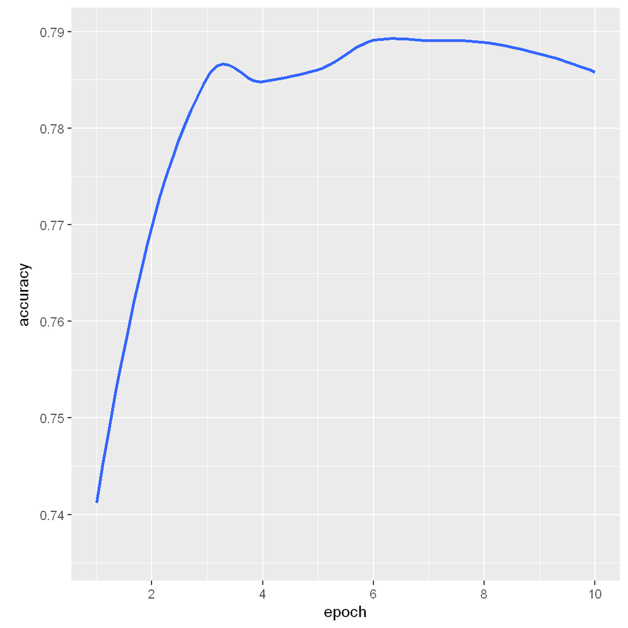

```r
plot(history.airline,metrics = "accuracy")
```

Now let’s see how it works on our validation data.

```r
keras.predict <- predict_classes(model.airline, keras.val.x)
keras.predict <- ifelse(keras.predict==1, "Not Delay", "Delay")
keras.predict <- as.factor(keras.predict)
confusionMatrix(keras.predict, val_y, "Delay")
```

```
Confusion Matrix and Statistics

           Reference
Prediction  Delay Not Delay
  Delay       646       129
  Not Delay   245       762

               Accuracy : 0.7901
                 95% CI : (0.7705, 0.8088)
    No Information Rate : 0.5
    P-Value [Acc > NIR] : < 0.00000000000000022

                  Kappa : 0.5802

 Mcnemar's Test P-Value : 0.000000002739

            Sensitivity : 0.7250
            Specificity : 0.8552
         Pos Pred Value : 0.8335
         Neg Pred Value : 0.7567
             Prevalence : 0.5000
         Detection Rate : 0.3625
   Detection Prevalence : 0.4349
      Balanced Accuracy : 0.7901

       'Positive' Class : Delay
```

The accuracy is nowhere near the random forest algorithm.

# 6 Model Tuning

I’ll recall the result of the base model

[output not shown]

As we have seen, Random Forest accuracy is far beyond other models, even Neural Network, so it is surely the best model for this case. However, eventhough the performance is great, we’re still able to embed some tunings, just to see if we can come up with a better result or not.

## 6.1 Parameter Tuning

There are several parameters that affect the result of a random forest model, but two of the most important part is **mtry**, number of variables used to split sample in each bootstrap, and **ntree**, number of trees used. If you’re using `caret` package, **k-fold cross validation** might be an option, but since we are using `randomForest` package, we will use `tuneRF()` instead, to find the optimum number of **mtry**. Also we’ll add up number of trees to 1000 trees.

```r
set.seed(16)
rf.airline.up <- tuneRF(train_x, train_y, trace = 0, plot = F, doBest = T, ntreeTry = 1000)
```

```
-0.007968127 0.05
-0.03784861 0.05
```

```r
rf.predict.up <- predict(rf.airline.up, val_x)
confusionMatrix(rf.predict.up, val_y, "Delay")
```

```
Confusion Matrix and Statistics

           Reference
Prediction  Delay Not Delay
  Delay       814        89
  Not Delay    77       802

               Accuracy : 0.9068
                 95% CI : (0.8924, 0.9199)
    No Information Rate : 0.5
    P-Value [Acc > NIR] : <0.0000000000000002

                  Kappa : 0.8137

 Mcnemar's Test P-Value : 0.3932

            Sensitivity : 0.9136
            Specificity : 0.9001
         Pos Pred Value : 0.9014
         Neg Pred Value : 0.9124
             Prevalence : 0.5000
         Detection Rate : 0.4568
   Detection Prevalence : 0.5067
      Balanced Accuracy : 0.9068

       'Positive' Class : Delay
```

[output not shown]

Not much of an improvement. Considering the process of the tuning, overall, model with no tuning is still better.

## 6.2 Threshold Shifting

Another tuning is by shifting the threshold. By default, most of machine learning algorithm, including Random Forest, using 0.5 as their threshold. However, shifting the threshold could produce a better result.

```r
optimum_threshold <- function(model, x_test, y_true, min = 0.30, max = 0.70, pos, neg){
  len <-  (max-min)*100
  metrics <- matrix(nrow = len, ncol = 5)
  for (i in 1:len){
    y_pred <- predict(model, x_test, type = "prob")
    y_pred <- ifelse(y_pred[,1]>min, pos,neg)
    y_pred <- as.factor(y_pred)
    metrics[i,1] = min
    metrics[i,2] = Accuracy(y_pred, y_true)
    metrics[i,3] = Precision(y_pred, y_true)
    metrics[i,4] = Sensitivity(y_pred, y_true)
    metrics[i,5] = Specificity(y_pred, y_true)
    min = min + 0.01
  }
  metrics <- as.data.frame(metrics)
  colnames(metrics) = c("Threshold", "Accuracy", "Precision", "Sensitivity", "Specificity")
  return(metrics)
}
```

```r
thres.airline <- optimum_threshold(model = rf.airline, x_test = val_x, y_true = val_y, pos = "Delay", neg = "Not Delay")
head(thres.airline)
```

```
  Threshold  Accuracy Precision Sensitivity Specificity
1      0.30 0.8417508 0.9506173   0.7806452   0.9368723
2      0.31 0.8456790 0.9506173   0.7857143   0.9375000
3      0.32 0.8484848 0.9483726   0.7904584   0.9354839
4      0.33 0.8546577 0.9483726   0.7986767   0.9364641
5      0.34 0.8574635 0.9427609   0.8053691   0.9309878
6      0.35 0.8591470 0.9360269   0.8112840   0.9244032
```

To explore more pattern from the table above, we can plot and see the trade off on each side

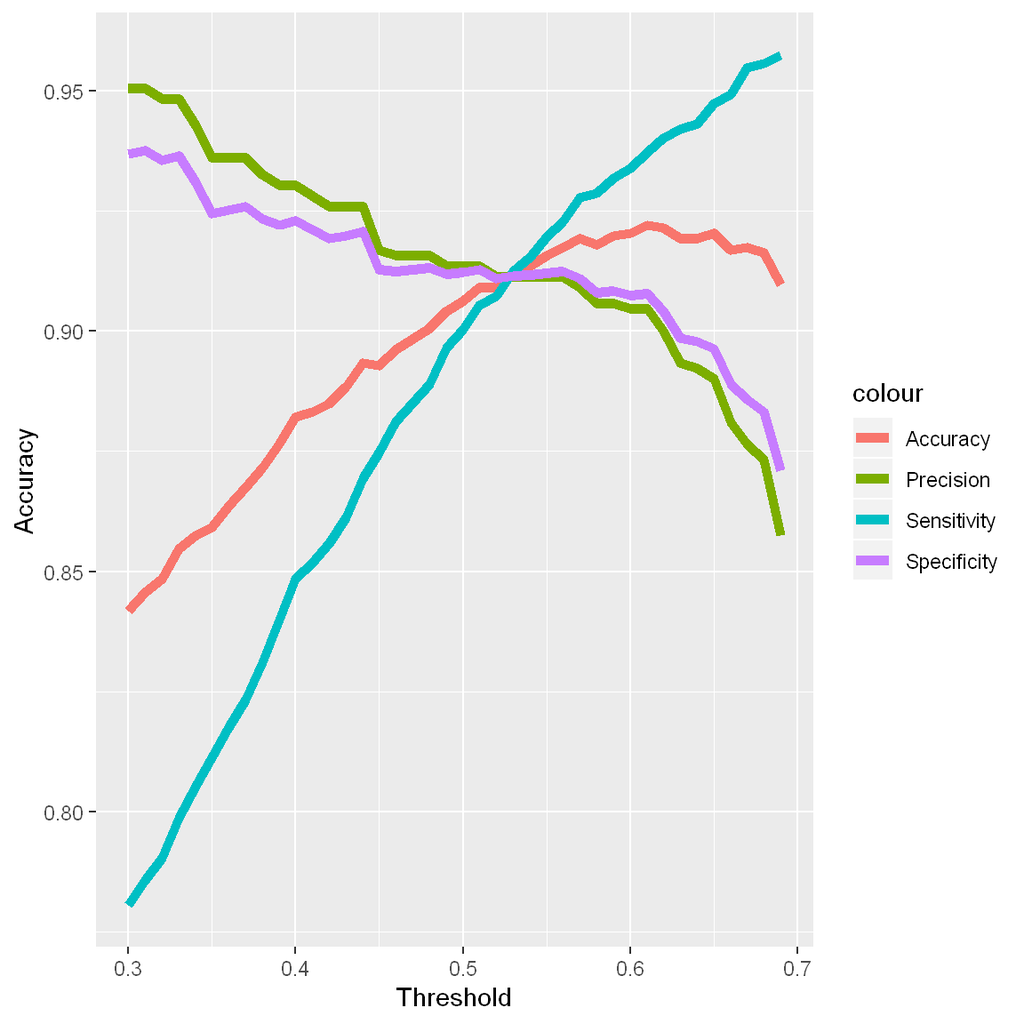

What insights can we observe from the plot above?

1. The higher the threshold, the higher the Sensitivity
2. The higher the threshold, the lower the Precision
3. Accuracy will follow the increase in threshold, until threshold ~ `0.6`
4. Specificity tends to be lower with the increase of threshold.

Overall, thresholds near to balanced are the most optimum one, which is around `0.56` to `0.62`. The numeric metrics imply that as well

```r
thres.airline %>% mutate(Overall = (Accuracy+Precision+Sensitivity+Specificity)/4) %>% round(2) %>% arrange(desc(Overall)) %>% head()
```

```
  Threshold Accuracy Precision Sensitivity Specificity Overall
1      0.56     0.92      0.91        0.92        0.91    0.92
2      0.57     0.92      0.91        0.93        0.91    0.92
3      0.58     0.92      0.91        0.93        0.91    0.92
4      0.59     0.92      0.91        0.93        0.91    0.92
5      0.60     0.92      0.90        0.93        0.91    0.92
6      0.61     0.92      0.90        0.94        0.91    0.92
```

Threshold around `0.56` and `0.62` has the highest Overall metrics (the most optimum). Thus, we will set the threshold to 0.56.

```r
# using type = "prob" will return probability value
rf.predict.set <- predict(rf.airline, val_x,"prob")

# the first column is the probabilities for Delay
rf.predict.set <- ifelse(rf.predict.set[,1]>0.56,"Delay","Not Delay")
rf.predict.set <- as.factor(rf.predict.set)
confusionMatrix(rf.predict.set, val_y)
```

```
Confusion Matrix and Statistics

           Reference
Prediction  Delay Not Delay
  Delay       812        68
  Not Delay    79       823

               Accuracy : 0.9175
                 95% CI : (0.9038, 0.9299)
    No Information Rate : 0.5
    P-Value [Acc > NIR] : <0.0000000000000002

                  Kappa : 0.835

 Mcnemar's Test P-Value : 0.4095

            Sensitivity : 0.9113
            Specificity : 0.9237
         Pos Pred Value : 0.9227
         Neg Pred Value : 0.9124
             Prevalence : 0.5000
         Detection Rate : 0.4557
   Detection Prevalence : 0.4938
      Balanced Accuracy : 0.9175

       'Positive' Class : Delay
```

And we can see that the result is a little bit better

# 7 Interpretation

As further interpretation, we will use Random Forest model without tuning.

## 7.1 Variable Importance

Before getting into the in-depth interpretation using `lime`, Random Forest function provides a simple interpretation by observing the importance of a variable

```r
impVar <- as.data.frame(importance(rf.airline))
impVar$Variable <- rownames(impVar)
rownames(impVar) <- NULL
impVar %>% select(Variable,MeanDecreaseGini) -> impVar
impVar
```

```
    Variable MeanDecreaseGini
1  dep_delay         917.2303
2   duration         174.2845
3       temp         190.2890
4       dewp         200.0736
5      humid         244.7256
6   wind_dir         180.7881
7 wind_speed         154.9532
```

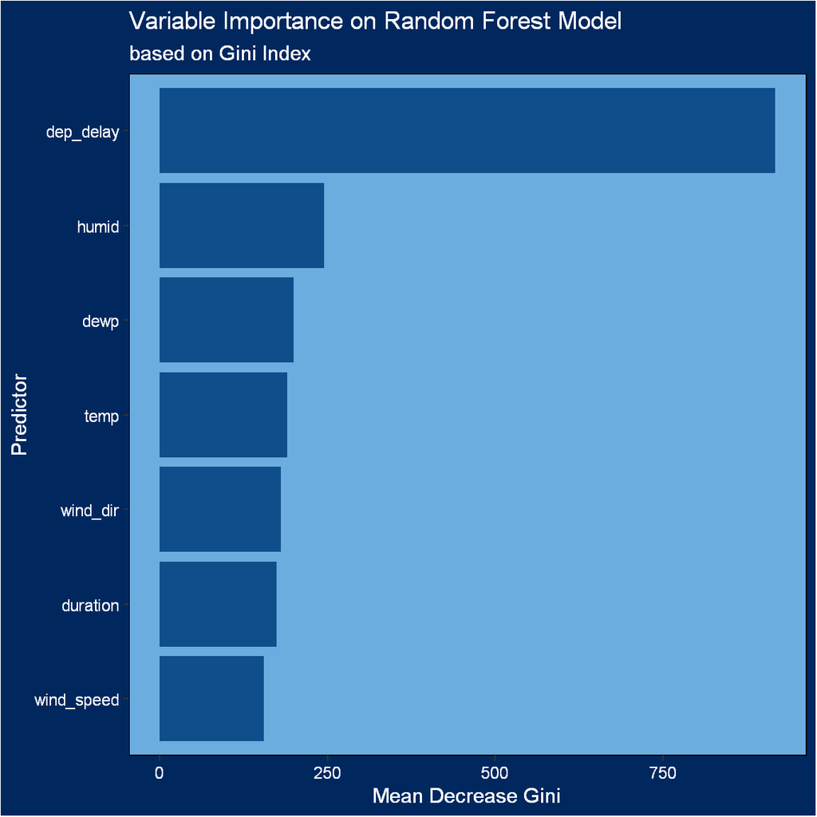

```r
ggplot(impVar, aes(x = reorder(Variable,MeanDecreaseGini), y = MeanDecreaseGini)) + geom_col(fill = "dodgerblue4") + coord_flip() +
  labs(title = "Variable Importance on Random Forest Model", subtitle = "based on Gini Index", x = "Predictor", y = "Mean Decrease Gini") +
  theme_airline + theme(legend.position = "none")
```

It tells us that the delay of departure have a strong relation with the delay status of a flight. Humidity is the second-highest influence in defining flight delay. For a clearer interpretation, we can use `lime` package.

## 7.2 Interpretation using `LIME`

LIME stands for **Local Interpretable Model-Agnostic Explanations**, and recently arising as interpreter for **black-box** machine learning such as random forest and neural network.

First, we need to tell `lime` that we are working on a classifier algorithm

```r
rf.lime <- as_classifier(rf.airline)
```

Then, we pass the parameters to the `lime()` function

```r
rf.exp <- lime(train_x, rf.lime)
```

Finally, we extract the explanation of the first 4 observations. `n_features` is number of features we want to use, and since we only have 7 features, we can use all of them.

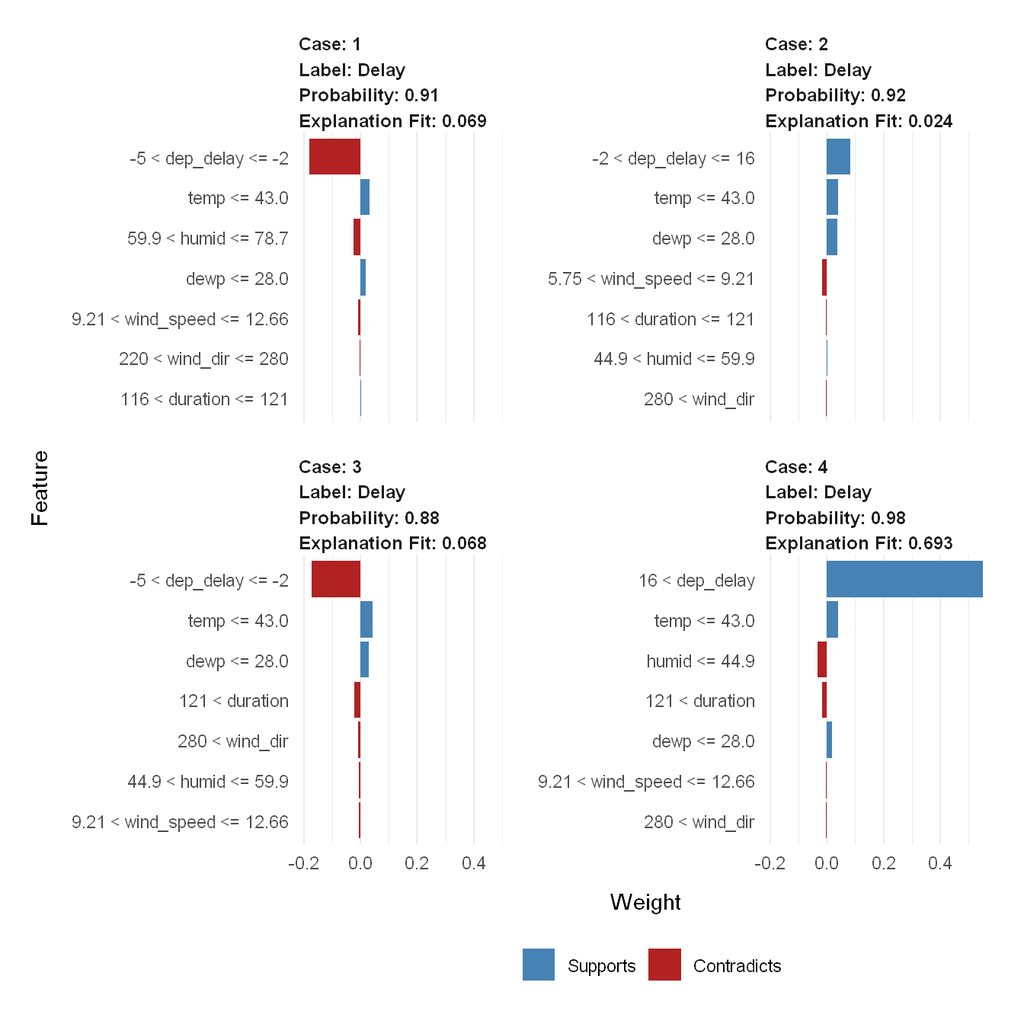

```r
rf.int <- explain(train_x[1:4,], rf.exp, "Delay", n_features = 7)
plot_features(rf.int)
```

`Case` means which observation is currently observed.

`Probability` is the probability of observations to be in the selected class, in this case, **Delay**.

We can tune in some parameters in lime to get the better explanation fit. Here I’ll use another distance function, and repeating the analysis process for 500 times.

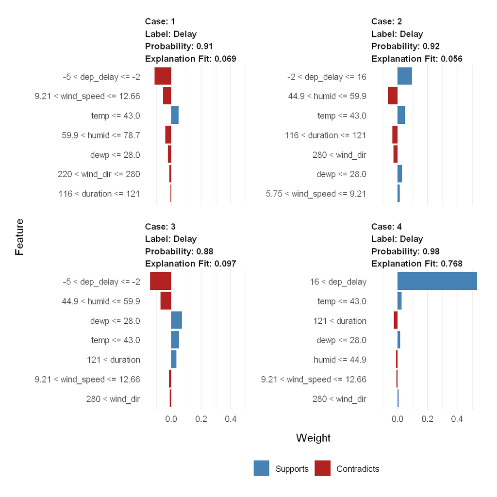

```r
rf.int.up <- explain(train_x[1:4,], rf.exp, labels = "Delay", n_features = 7, dist_fun = "manhattan", kernel_width = 3, n_permutations = 500)
plot_features(rf.int.up)
```

We see an improvement, now we have a more convincing interpretation of our model. Now let’s focus on the 4th observation.

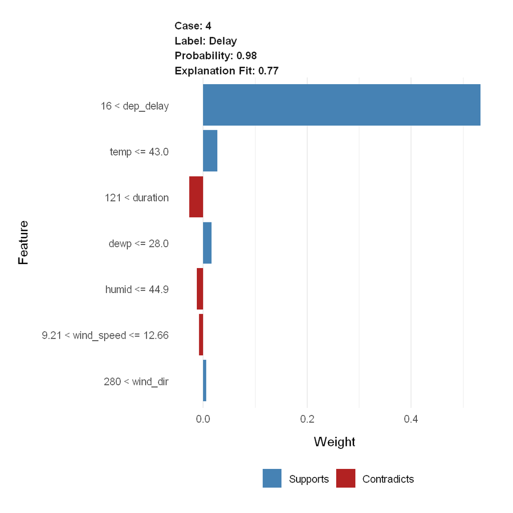

```r
# we subset 7th last features
plot_features(rf.int.up[22:28,])
```

The blue bar tells that this variable is supporting the observation to be classified as positive class (**Delay**), while the red bar contradicting. The number of weight is how strong the influence of a variable to push/classify an observation into its desired direction.

We can extract the exact weight by assigning the plot into an object, and then subsetting the `data` from the object

```r
rf.plot <- plot_features(rf.int.up)
rf.plot$data[22:28,] %>% select(feature, feature_desc, feature_weight)
```

```
# A tibble: 7 x 3
  feature    feature_desc               feature_weight
  <chr>      <chr>                               <dbl>
1 dep_delay  16 < dep_delay                    0.533
2 duration   121 < duration                   -0.0268
3 temp       temp <= 43.0                      0.0274
4 dewp       dewp <= 28.0                      0.0160
5 humid      humid <= 44.9                    -0.0121
6 wind_dir   280 < wind_dir                    0.00556
7 wind_speed 9.21 < wind_speed <= 12.66       -0.00806
```

## 7.3 Comparison

After observing how `LIME` works, we can compare the performance to `varImp()` from random forest, or against interpretable machine learning model like Logistic Regression

> Advantages:
1. LIME can explain how each variable affects the observation’s probability to be classified as positive class.
2. LIME has explanation fit, so our interpretation is more reassuring and reliable
3. We can choose which observation we want to analyze. For example, we want to analyze the pattern in July, we can subset observations in July and see which variables affect the flight status. Even interpretable model like **Logistic Regression** doesn’t have this feature.

> Disadvantages:
1. Cannot explain the variable importance to all data, we need to observe each observation, and for large dataset, it would take time.
2. Need to tune explanation fit since it tends to be in a very low score.
3. Need some process, so it is slower than `varImp()` or interpretable machine learning

# 8 Conclusion

## 8.1 Test Dataset

The model works quite well on the test dataset, provides over `70%` in all metrics

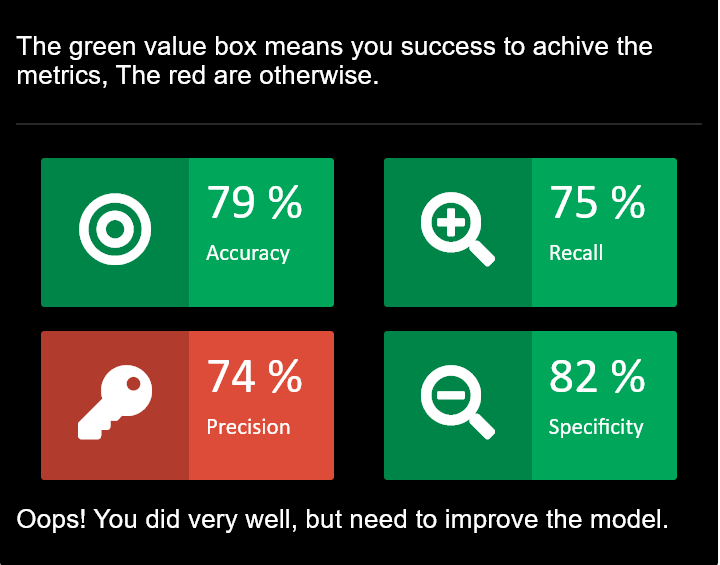

## 8.2 Business Case

[output not shown]

With all over 90% metrics, we can safely say that our goal is achieved, predicting flight delay by using machine learning model. If we recall to the **Introduction** section, we know that customers will choose flights which, has less delay, or if the delay is unavoidable, the customers got an early warning so that they don’t have to spend time and energy to go to the airport. Thus, with this impressive accuracy, we will less likely to do sudden delay, which substantially will attract more customers to choose our airline.